# Analyzing the Relationship Between Mean Years of Women in Higher Education with Life Expectancy

Author

Zachary Weinfeld, Gabby Low, Brett Kuwahara, Shea Tennison

**Research Question: We will analyze the correlation between life expectancy and the mean years 15-24 year old women are in school across different countries.**

# Preliminary Data Analysis

### Data Description

Life expectancy contains data about the expected lifespan of person. This is broken down by country and year, where each observation is a country and each variable is a year. Similarly, school years contains data about the average number of years women from the ages 15 to 24 are in school. This data is also broken down by country and year, where each observation is a country and each variable is a year.

Our data is obtained from Gapminder. Here is how Gapminder collects data:

> “Our method is simple: First, we ask thousands of questions to the public in many countries to see what they think the world looks like. Then, we check data from reliable sources and identify the worst global misconceptions.”

> -Gapminder

Additionally, Gapminder provided these descriptions for each dataset:

- `Life Expectancy`: The number of years a newborn infant would live if the current mortality rates at different ages were to stay the same throughout its life.
- `Mean Years in School (Women 15-24)`: The average number of years of school attended by women ages 15-24, including primary, secondary, and tertiary education.

Note: throughout this article, we will refer to “mean years of 15-24 year old women in school” as simply “mean years in school.”

### Data Cleaning Process

Fortunately, Gapminder put the data in a very clean format. However, there is much more data available for life expectancy than there is for school years. For life expectancy, data is available for every year from 1800 through 2100 (projection), but for school years, there is only data available for the years 1970 through 2015. For these years, there are 7 countries with missing values, and we made the decision to remove these countries from our analysis. For the remaining 188 countries with data present, we will focus on only the years 1970 through 2015.

### Hypothesized Relationship

We assume there will be a positive correlation between the two variables. A [study](https://news.yale.edu/2020/02/20/want-live-longer-stay-school-study-suggests#:~:text=Each%20educational%20step%20obtained%20led,are%20powerful%2C%E2%80%9D%20Roy%20said.) done by Yale University concluded that, on average, “Each educational step obtained led to 1.37 fewer years of lost life expectancy.” We expect our results to be consistent with the Yale study’s findings. Additionally, as an educated guess, it seems intuitive that countries with more women in school will have higher life expectancy; this may be due to other lurking variables, however. Both of these variables are likely correlated with the degree to how developed the country is. For example, a more developed country such as the US may have a long life expectancy *and* a high schooling rate in parallel, whereas a less developed country may have both of these values lower.

# Data Visualization and Relationship

We will first crudely examine the obvious visual patterns present in the data.

## Observable Relationship Between the Variables

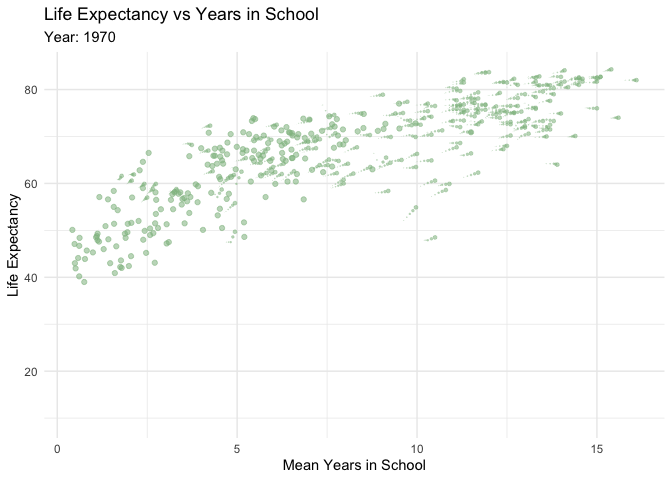

The above plot shows the relationship between the two variables over time. Each frame of the animation represents a year. The animation shows the general trajectory of the variables—in general, they both increase for a given country over time.

## Change in Variables over Time

We will examine the average value of each metric for a given year across all countries in the dataset.

[figure not shown]

For the above plot, we chose to scale the values between 0 and 1. This is because the range of values for the two different metrics is very different. Mean years in school typically instantiates around 2 to 12, while mean life expectancy typically instantiates around 50 to 80. If both were plotted on top of each other without scaling, it would be very difficult to see the line representing mean years in school in the resultant plot.

Before we dive into linear regression, lets look into the relationship between the *mean* life expectancy per country and *mean* years in school per country, averaged across the years 1970 through 2015 for each individual country. This is the data that we will perform linear regression on.

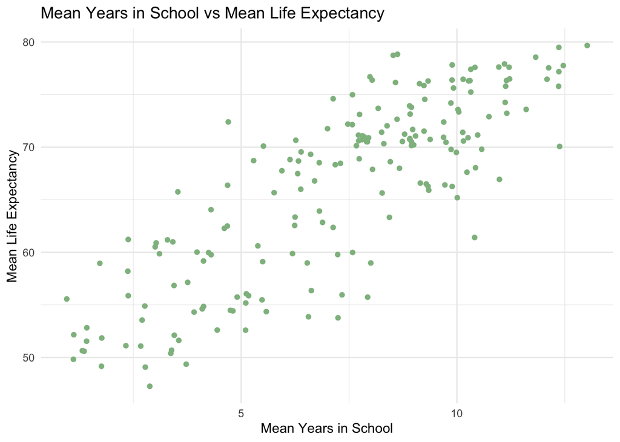

# Linear Regression

Linear regression is a type of statistical analysis used to predict the relationship between two variables, particularly when there appears to be a linear relationship between them.

### Conditions for Linear Regression

In order for a linear regression model to be appropriate on a dataset, four conditions must be met. There must be an approximately linear relationship between the variables of interest, the observations must be independent, the residuals must be normally distributes, and the residuals must have equal variance. In this dataset, there is an approximately linear relationship between mean years in school and mean life expectancy. Each of the observations are independent as the values of the variables in one country do not influence those of another country. Lastly, the residuals appear to be normally distributed and have equal variance. Therefore, it is appropriate to apply a linear model to our dataset.

Presented below are the summary statistics of the linear model:

| term | estimate | std.error | statistic | p.value |
| --- | --- | --- | --- | --- |
| Intercept | 48.840077 | 0.9304586 | 52.49033 | 0 |
| Mean School Years | 2.388605 | 0.1186571 | 20.13031 | 0 |

## Linear Regression Equation

Based on the above table, we can produce the least squares regression equation as follows:

$$\huge
\hat{y}=48.84 + 2.39x$$

- $\hat{y}=predicted\ life\ expectancy$
- $x=mean\ years\ in\ school$

### Interpreting the Linear Regression Coefficients

For a given country, for every additional mean year in school for 15-24 year old women, we expect the life expectancy to increase by 2.39 years.

For a country with a mean of zero school years of 15-24 year old women, we expect the life expectancy for that country to be 48.84 years. Note: this is an extrapolation of the model, and thus may not be accurate.

### Describing the Fit of the Regression Model

The $R^{2}$ is 0.685 which means that 68.5% of the mean life expectancy can be explained from our model.

### Variance Across our Response, Fitted, and Residual Values

[output not shown]

The above table shows that the variance in our fitted values is larger than our variance in our residuals. This indicates that our model explains a larger portion of the variation in the data compared to the unexplained variation. The response values variation is the total variation in mean life expectancy, without regarding mean years in school.

# Predictions

Let’s compare the actual life expectancy for each country with the predicted values.

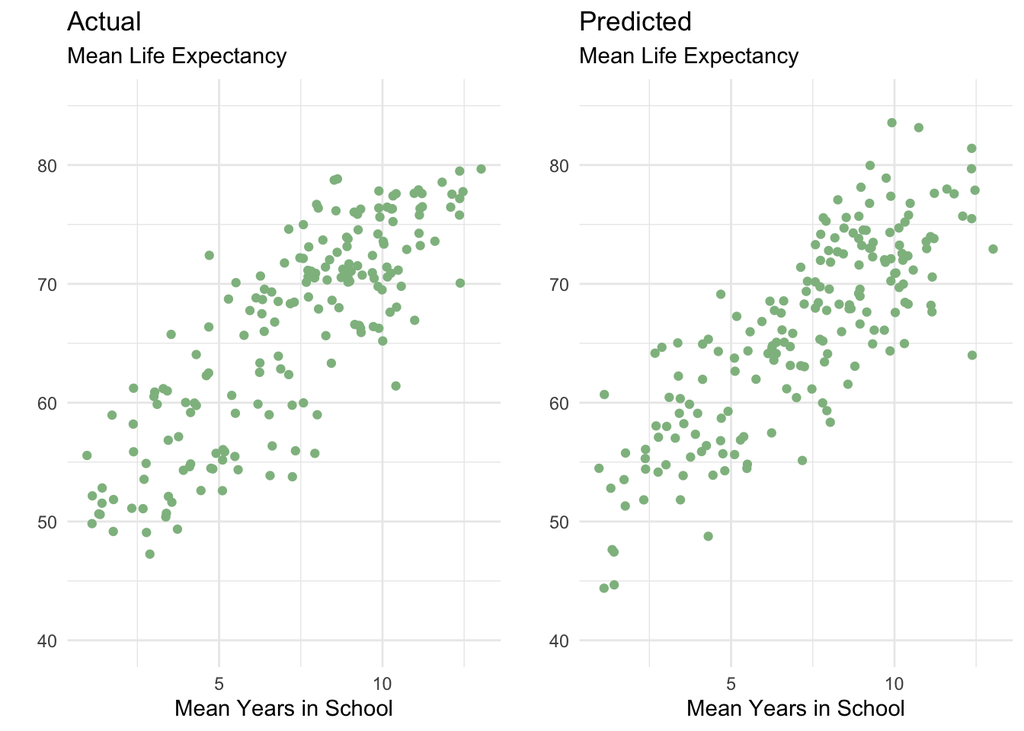

# Simulation

We were interested in seeing how our model performs over many different datasets. We will do this by performing predictive checks. This is an important statistical concept, since our data only instantiates one of billions of possible abstractions. Thus, we simulated 1000 realistic datasets based on the fitted model above.

For each generated dataset, we fit a linear regression model to it and calculated the $R^2$ value.

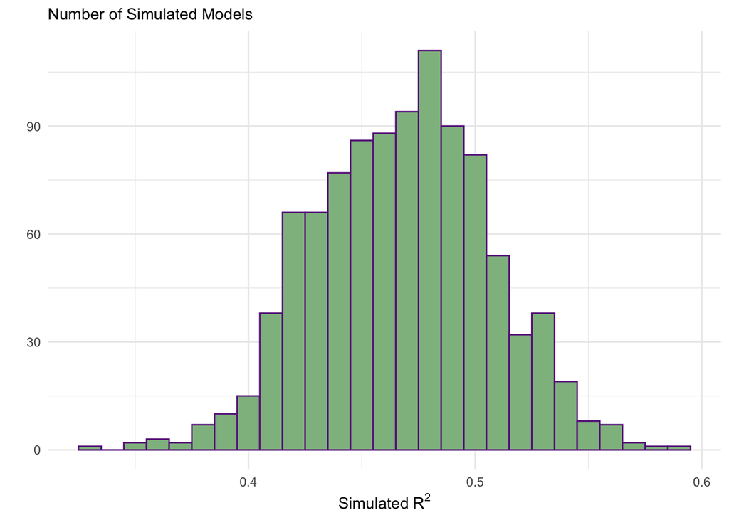

The above histogram shows the $R^{2}$ values for the 1000 simulations. This follows an approximately normal distribution.

# Conclusion

From our original dataset, we fit a linear model with the explanatory variable “mean years in school” and the response variable “life expectancy.” This model had an $R^{2}$ value of 0.685. From this, we can infer that while our model is a somewhat adequate predictor, there is a lot of variation in the response variable that cannot be explained by the regression model. There is some degree of correlation between the two variables. However, since this was an observational study and not an experiment, we cannot conclude a causal relationship between the two variables. As explained above, it is likely that there are other lurking variables at play that are responsible for this linear relationship. Further investigation beyond the scope of this paper would need to be done to determine if a causal relationship exists.

# References

1. Yale University News: “Want to Live Longer? Stay in School, Study Suggests.” Yale News, 20 Feb. 2020, [**https://news.yale.edu/2020/02/20/want-live-longer-stay-school-study-suggests**](https://news.yale.edu/2020/02/20/want-live-longer-stay-school-study-suggests).
2. Jim Frost. “How to Interpret the R-squared Value in Regression.” Statistics By Jim, [**https://statisticsbyjim.com/regression/interpret-r-squared-regression/**](https://statisticsbyjim.com/regression/interpret-r-squared-regression/).